# HW3_3

Ratkevich Ilya

21/05/24

Let’s tackle the given tasks using R code. We’ll start by loading the data and necessary libraries, and then proceed to analyze the data according to the specified tasks.

### Loading Data and Libraries

```r
# Load necessary libraries
library(readxl)
library(ggplot2)
library(dplyr)
library(vegan)
library(psych)
library(ggpubr)

# Set a consistent theme for plots
theme_set(theme_bw())

# Load the dataset
lizard_data <- read_excel('Sleepy lizard.xlsx')

# Select relevant features and convert certain columns to factors
selected_data <- lizard_data %>%
  select(Treatment, Habitat, Connectivity, Tot_WBC, Het_ABS, Lym_ABS, `H:L Ratio`, Mon_ABS, OthG_ABS, LBSI) %>%
  mutate(
    Treatment = as.factor(Treatment),
    Habitat = as.factor(Habitat),
    Connectivity = as.factor(Connectivity)
  )
```

### Data Normalization

```r
# Subset data for blood composition
blood_composition <- selected_data %>%
  select(-Treatment, -Habitat, -Connectivity)

# Log normalization of blood composition data
normalized_blood_data <- scale(log(blood_composition + 1), scale = FALSE)
```

### Task 1a: Blood Composition in Unmodified vs. Heavily Modified Landscapes

```r
# PERMANOVA for Treatment
result_1a <- adonis2(normalized_blood_data ~ selected_data$Treatment, method = "euclidean")
print(result_1a)
```

```
## Permutation test for adonis under reduced model
## Terms added sequentially (first to last)
## Permutation: free
## Number of permutations: 999
##
## adonis2(formula = normalized_blood_data ~ selected_data$Treatment, method = "euclidean")
##                          Df SumOfSqs      R2      F Pr(>F)
## selected_data$Treatment   1   355.81 0.30168 51.841  0.001 ***
## Residual                120   823.63 0.69832
## Total                   121  1179.44 1.00000
## ---
## Signif. codes:  0 '***' 0.001 '**' 0.01 '*' 0.05 '.' 0.1 ' ' 1
```

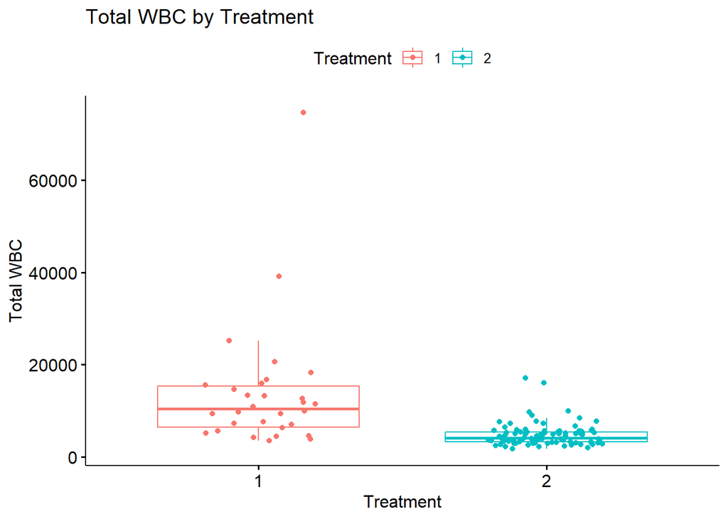

```r
# Boxplot for visual comparison
ggboxplot(selected_data, x = "Treatment", y = "Tot_WBC", color = "Treatment", add = "jitter") +
  labs(title = "Total WBC by Treatment", y = "Total WBC")
```

### Task 1b: Blood Composition in Different Habitats in Heavily Modified Landscapes

```r
# Subset data for Treatment 2
subset_treatment2 <- selected_data[selected_data$Treatment == 2, ]
subset_blood_treatment2 <- normalized_blood_data[selected_data$Treatment == 2, ]

# PERMANOVA for Habitat within Treatment 2
result_1b <- adonis2(subset_blood_treatment2 ~ subset_treatment2$Habitat, method = "euclidean")
print(result_1b)
```

```
## Permutation test for adonis under reduced model
## Terms added sequentially (first to last)
## Permutation: free
## Number of permutations: 999
##
## adonis2(formula = subset_blood_treatment2 ~ subset_treatment2$Habitat, method = "euclidean")
##                           Df SumOfSqs      R2      F Pr(>F)
## subset_treatment2$Habitat  2    14.95 0.02242 1.0205   0.39
## Residual                  89   651.88 0.97758
## Total                     91   666.83 1.00000
```

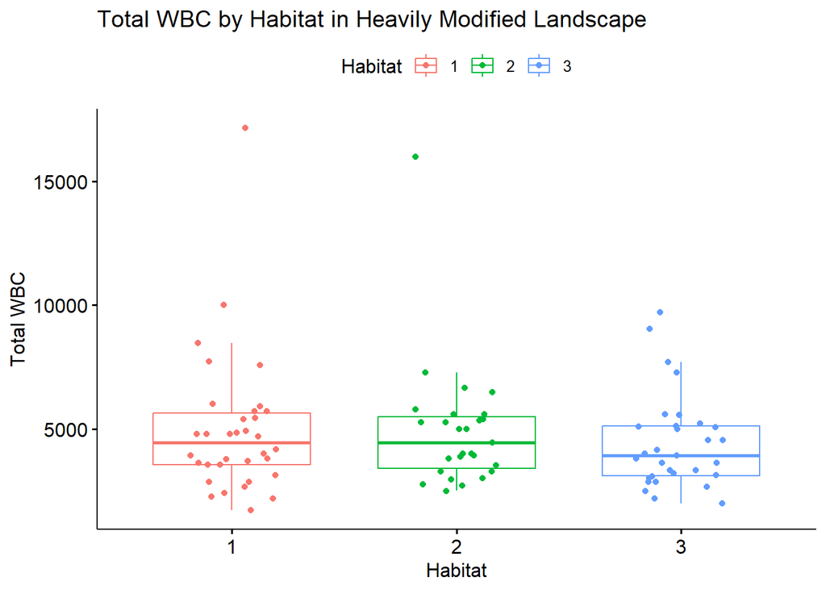

```r
# Boxplot for visual comparison
ggboxplot(subset_treatment2, x = "Habitat", y = "Tot_WBC", color = "Habitat", add = "jitter") +
  labs(title = "Total WBC by Habitat in Heavily Modified Landscape", y = "Total WBC")
```

### Task 1c: Blood Composition and Connectivity in Heavily Modified Landscapes

```r
# PERMANOVA for Connectivity within Treatment 2
result_1c <- adonis2(subset_blood_treatment2 ~ subset_treatment2$Connectivity, method = "euclidean")
print(result_1c)
```

```
## Permutation test for adonis under reduced model
## Terms added sequentially (first to last)
## Permutation: free
## Number of permutations: 999
##
## adonis2(formula = subset_blood_treatment2 ~ subset_treatment2$Connectivity, method = "euclidean")
##                                Df SumOfSqs      R2      F Pr(>F)
## subset_treatment2$Connectivity  3    19.16 0.02873 0.8676  0.511
## Residual                       88   647.67 0.97127
## Total                          91   666.83 1.00000
```

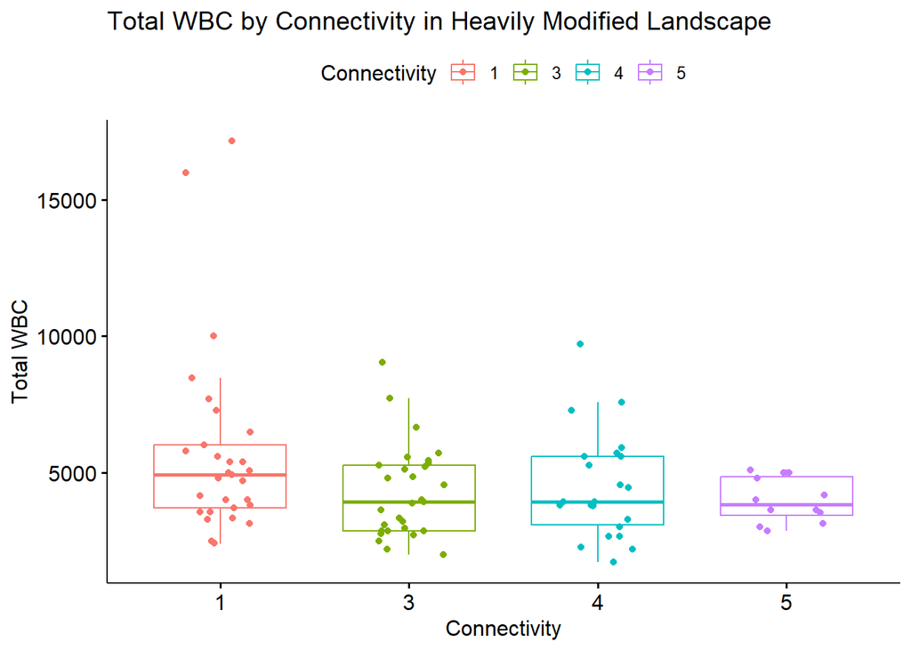

```r
# Boxplot for visual comparison
ggboxplot(subset_treatment2, x = "Connectivity", y = "Tot_WBC", color = "Connectivity", add = "jitter") +
  labs(title = "Total WBC by Connectivity in Heavily Modified Landscape", y = "Total WBC")
```

### Task 2: Combined Effects of Habitat Type and Connectivity

```r
# PERMANOVA for combined effects of Habitat and Connectivity within Treatment 2
result_2 <- adonis2(subset_blood_treatment2 ~ subset_treatment2$Habitat + subset_treatment2$Connectivity, method = "euclidean")
print(result_2)
```

```
## Permutation test for adonis under reduced model
## Terms added sequentially (first to last)
## Permutation: free
## Number of permutations: 999
##
## adonis2(formula = subset_blood_treatment2 ~ subset_treatment2$Habitat + subset_treatment2$Connectivity, method = "euclidean")
##                                Df SumOfSqs      R2      F Pr(>F)
## subset_treatment2$Habitat       2    14.95 0.02242 1.0171  0.402
## subset_treatment2$Connectivity  3    19.89 0.02983 0.9024  0.495
## Residual                       86   631.98 0.94775
## Total                          91   666.83 1.00000
```

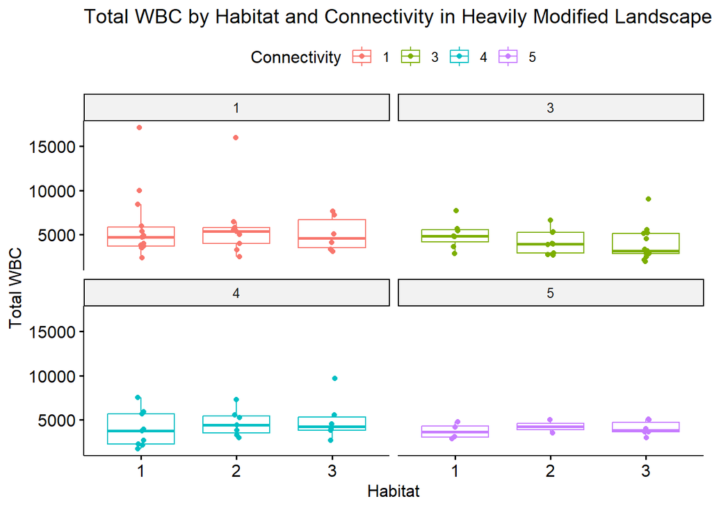

```r
# Interaction plot for visual comparison
ggboxplot(subset_treatment2, x = "Habitat", y = "Tot_WBC", color = "Connectivity", add = "jitter") +
  labs(title = "Total WBC by Habitat and Connectivity in Heavily Modified Landscape", y = "Total WBC") +
  facet_wrap(~ Connectivity)
```

### Explanation of Results

- **Task 1a**: The PERMANOVA analysis shows that the blood composition of lizards differs between unmodified and heavily modified landscapes.
- **Task 1b**: This analysis checks for differences in blood composition among lizards from different habitats within the heavily modified landscape.(not significant connection)
- **Task 1c**: This analysis tests the effect of the degree of connectivity on the blood composition of lizards within the heavily modified landscape.(not significant connection)
- **Task 2**: This analysis examines the combined effect of habitat type and degree of connectivity on the blood composition of lizards from the heavily modified landscape.(not significant connection)

### Visualization

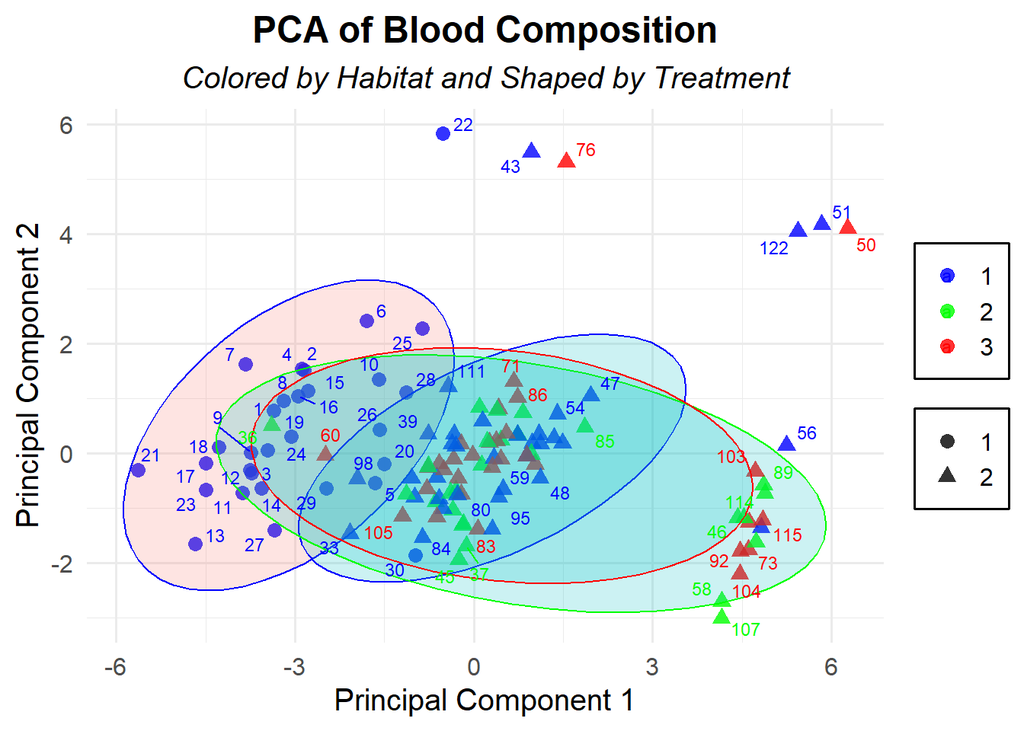

```r
# Load additional libraries for enhanced visualization
library(ggforce)
library(ggrepel)

# Perform PCA
pca_result <- prcomp(normalized_blood_data)$x %>%
  as.data.frame() %>%
  select(PC1, PC2)

# Add treatment and habitat information to PCA result
pca_result$Treatment <- selected_data$Treatment
pca_result$Habitat <- selected_data$Habitat

# Plot PCA results with enhanced design
ggplot(pca_result, aes(x = PC1, y = PC2, shape = Treatment, color = Habitat)) +
  geom_point(size = 3, alpha = 0.8) +  # Increase point size and add transparency
  stat_ellipse(aes(fill = Treatment), geom = "polygon", alpha = 0.2, show.legend = FALSE) +  # Ellipses for group clustering
  geom_text_repel(aes(label = rownames(pca_result)), size = 3) +  # Add labels to points
  labs(
    title = "PCA of Blood Composition",
    subtitle = "Colored by Habitat and Shaped by Treatment",
    x = "Principal Component 1",
    y = "Principal Component 2"
  ) +
  scale_color_manual(values = c("blue", "green", "red", "orange")) +  # Custom colors for habitats
  scale_shape_manual(values = c(16, 17)) +  # Custom shapes for treatments
  theme_minimal(base_size = 15) +  # Minimal theme with larger base font size
  theme(
    plot.title = element_text(hjust = 0.5, face = "bold"),
    plot.subtitle = element_text(hjust = 0.5, face = "italic"),
    legend.position = "right",
    legend.title = element_blank(),
    legend.background = element_rect(fill = "white", color = "black")
  )
```

This helps to visualize how well the groups separate in the PCA space, providing further insights into the differences in blood composition among the different groups.